# Skills Quiz: Different Types of Models

## Instructions

Use this file to keep a record of your work as you complete the “Skills Quiz: Different Types of Models” assignment in Canvas.

```r
library(mosaicData)
library(tidyverse)
```

## Problem 1

Consider the scatterplot shown here of a single residence’s monthly gas bill according to the month of the year. See `?Utilities` for more details on the data.

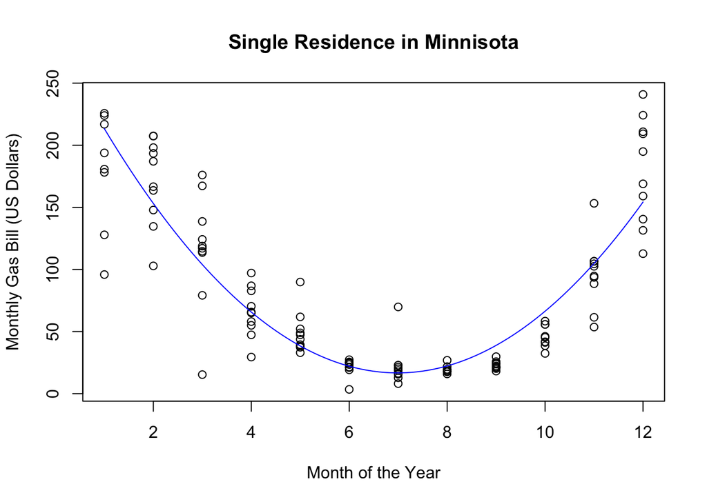

```r
plot(gasbill ~ month, data=Utilities, main="Single Residence in Minnisota", xlab="Month of the Year", ylab="Monthly Gas Bill (US Dollars)")

utilities.lm <- lm(gasbill ~ month + I(month^2), data = Utilities)

b <- utilities.lm$coefficients

curve(b[1] + b[2] * x + b[3] * x^2, col = "blue", add = T)
```

### Part (a)

Add the estimated regression function to the scatterplot above and state the function below.

### Part (b)

Diagnose the appropriateness of this regression model. How well does it fit the data?

Be sure to provide diagnostic plots and supporting arguments for your claims.

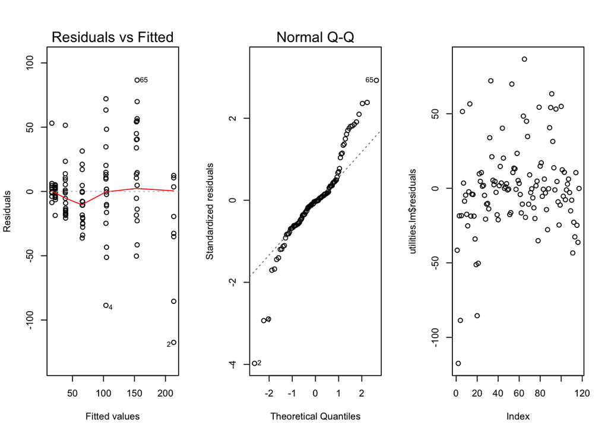

```r
par(mfrow = c(1,3))
plot(utilities.lm, which = 1:2)
plot(utilities.lm$residuals)
```

### Part (c)

What range of possible gas bill amounts do you predict for the September bill? How confident are you in your prediction?

```r
predict(utilities.lm, data.frame(month = 9), interval = "prediction")
```

```
##        fit       lwr      upr
## 1 38.84658 -22.00324 99.69641
```

### Part (d)

Compute the mean of just September’s gas bills and draw a horizontal reference line for this mean on your scatterplot. How does this mean compare to your prediction in Part (c)?

```r
sep_utilities <- Utilities %>%
  filter(month == 9)

a <- sep_utilities %>%
  summarize(mean = mean(gasbill))

38.84658 - a
```

```
##       mean
## 1 16.03158
```

### Part (e)

State the values of $R^2$, $MSE$, and the residual standard error. What do each of these values tell us about the regression model?

```r
summary(utilities.lm)
```

```
##
## Call:
## lm(formula = gasbill ~ month + I(month^2), data = Utilities)
##
## Residuals:
##      Min       1Q   Median       3Q      Max
## -117.440  -15.127   -0.692   10.528   86.617
##
## Coefficients:
##             Estimate Std. Error t value Pr(>|t|)
## (Intercept) 284.4558    10.5374   27.00   <2e-16 ***
## month       -76.6165     3.6609  -20.93   <2e-16 ***
## I(month^2)    5.4807     0.2712   20.21   <2e-16 ***
## ---
## Signif. codes:  0 '***' 0.001 '**' 0.01 '*' 0.05 '.' 0.1 ' ' 1
##
## Residual standard error: 30.48 on 114 degrees of freedom
## Multiple R-squared:  0.7937, Adjusted R-squared:  0.7901
## F-statistic: 219.3 on 2 and 114 DF,  p-value: < 2.2e-16
```

## Problem 2

View the `mtcars` dataset and corresponding help file `?mtcars`.

Perform a regression that predicts the miles per gallon `mpg` of the vehicle based on the quarter mile time `qsec` and transmission type `am` of the vehicle.

### Part (a)

Plot the data and your fitted regression model.

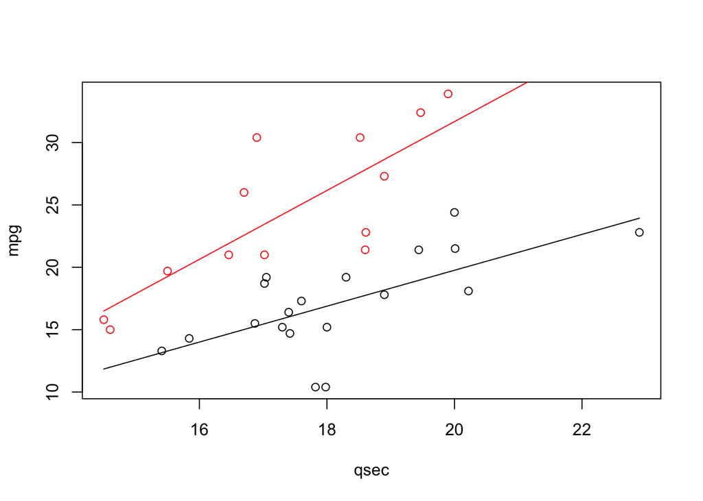

```r
par(mfrow = c(1,1))
plot(mpg ~ qsec, data = mtcars, col = as.factor(am))
mt.lm <- lm(mpg ~ qsec + am + qsec:am, data = mtcars)
b <- mt.lm$coefficients

x2=0
curve(b[1] + b[2]*x + b[3]*x2 + b[4]*x*x2, add = T, col = "black")
x2=1
curve(b[1] + b[2]*x + b[3]*x2 + b[4]*x*x2, add = T, col = "red")
```

### Part (b)

State the fitted regression model.

$$\underbrace{\hat{Y_i}}_\text{mean mpg} = -9.009861 + 1.4385416\underbrace{X_\text{1i}}_\text{qsec} + -14.5106855X_{2i} + 1.3214154X_\text{1i}X_\text{2i} + \epsilon_i$$

### Part (c)

Use `summary(...)` to perform an appropriate t test to determine if the interaction term is needed in this regression model.

```r
summary(mt.lm)
```

```
##
## Call:
## lm(formula = mpg ~ qsec + am + qsec:am, data = mtcars)
##
## Residuals:
##     Min      1Q  Median      3Q     Max
## -6.4551 -1.4331  0.1918  2.2493  7.2773
##
## Coefficients:
##             Estimate Std. Error t value Pr(>|t|)
## (Intercept)  -9.0099     8.2179  -1.096  0.28226
## qsec          1.4385     0.4500   3.197  0.00343 **
## am          -14.5107    12.4812  -1.163  0.25481
## qsec:am       1.3214     0.7017   1.883  0.07012 .
## ---
## Signif. codes:  0 '***' 0.001 '**' 0.01 '*' 0.05 '.' 0.1 ' ' 1
##
## Residual standard error: 3.343 on 28 degrees of freedom
## Multiple R-squared:  0.722,  Adjusted R-squared:  0.6923
## F-statistic: 24.24 on 3 and 28 DF,  p-value: 6.129e-08
```